# R Guide for TMLE in Medical Research

2021-08-18

# Preface

## Background

In comparative effectiveness studies, researchers typically use propensity score methods. However, propensity score methods have known limitations in real-world scenarios, when the true data generating mechanism is unknown. Targeted maximum likelihood estimation (TMLE) is an alternative estimation method with a number of desirable statistical properties. It is a doubly robust method, making use of both the outcome model and propensity score model to generate an unbiased estimate as long as at least one of the models is correctly specified. TMLE also enables the integration of machine learning approaches. Despite the fact that this method has been shown to perform better than propensity score methods in a variety of scenarios, it is not widely used in medical research as the technical details of this approach are generally not well understood.

## Goal

In this workshop we will present an introductory tutorial explaining an overview of TMLE using one real epidemiological data, the steps to use the method in R, and a demonstration of relevant R packages.

## Philosophy

Code-first philosophy is adopted for this workshop; demonstrating the analyses through one real data analysis problem used in the literature. This workshop is not theory-focused, nor utilizes simulated data to explain the ideas.

## Pre-requisites

Basic understanding of *R* language is required. A general understanding of *multiple regression* is expected. Familiarity with *machine learning* and *epidemiological* core concepts would be helpful, but not required. Deep understanding of *causal inference* or *advanced statistical inference* knowledge is not expected.

## Version history

The workshop was first developed for [R/Medicine Virtual Conference](https://r-medicine.org/schedule/) 2021, August 24th; title: `An Introductory R Guide for Targeted Maximum Likelihood Estimation in Medical Research’.

## Contributor list

| [Hanna Frank](https://www.linkedin.com/in/hanna-f-940813b9/) (SPPH, UBC) | [Ehsan Karim](https://ehsank.com/) (SPPH, UBC) |
| --- | --- |

## License

The online version of this book is licensed under the [Creative Commons Attribution-NonCommercial-ShareAlike 4.0](https://creativecommons.org/licenses/by-nc-sa/4.0/) International License. You may share, adapt the content and may distribute your contributions under the same license (CC BY-NC-SA 4.0), but you have to give appropriate credit, and cannot use material for the commercial purposes.

# 1 RHC data description

There is a widespread belief among cardiologists that the right heart catheterization (RHC hereafter; a monitoring device for measurement of cardiac function) is helpful in managing critically ill patients in the intensive care unit. Connors et al. (1996) examined the association of

- *RHC use* during the first 24 hours of care in the intensive care unit and
- a number of health-outcomes such as *length of stay* (hospital).

## 1.1 Data download

Data is freely available from [Vanderbilt Biostatistics](https://hbiostat.org/data/).

```r
# load the dataset
ObsData <- read.csv("https://hbiostat.org/data/repo/rhc.csv", header = TRUE)
saveRDS(ObsData, file = "data/rhc.RDS")
```

## 1.2 Analytic data

```r
# add column for outcome Y: length of stay
# Y = date of discharge - study admission date
# Y = date of death - study admission date if date of discharge not available
ObsData$Y <- ObsData$dschdte - ObsData$sadmdte
ObsData$Y[is.na(ObsData$Y)] <- ObsData$dthdte[is.na(ObsData$Y)] -
  ObsData$sadmdte[is.na(ObsData$Y)]
# remove outcomes we are not examining in this example
ObsData <- dplyr::select(ObsData,
                         !c(dthdte, lstctdte, dschdte, death, t3d30, dth30, surv2md1))
# remove unnecessary and problematic variables
ObsData <- dplyr::select(ObsData,
                         !c(sadmdte, ptid, X, adld3p, urin1, cat2))

# convert all categorical variables to factors
factors <- c("cat1", "ca", "cardiohx", "chfhx", "dementhx", "psychhx",
             "chrpulhx", "renalhx", "liverhx", "gibledhx", "malighx",
             "immunhx", "transhx", "amihx", "sex", "dnr1", "ninsclas",
             "resp", "card", "neuro", "gastr", "renal", "meta", "hema",
             "seps", "trauma", "ortho", "race", "income")
ObsData[factors] <- lapply(ObsData[factors], as.factor)
# convert our treatment A (RHC vs. No RHC) to a binary variable
ObsData$A <- ifelse(ObsData$swang1 == "RHC", 1, 0)
ObsData <- dplyr::select(ObsData, !swang1)
# Categorize the variables to match with the original paper
ObsData$age <- cut(ObsData$age,breaks=c(-Inf, 50, 60, 70, 80, Inf),right=FALSE)
ObsData$race <- factor(ObsData$race, levels=c("white","black","other"))
ObsData$sex <- as.factor(ObsData$sex)
ObsData$sex <- relevel(ObsData$sex, ref = "Male")
ObsData$cat1 <- as.factor(ObsData$cat1)
levels(ObsData$cat1) <- c("ARF","CHF","Other","Other","Other",
                          "Other","Other","MOSF","MOSF")
ObsData$ca <- as.factor(ObsData$ca)
levels(ObsData$ca) <- c("Metastatic","None","Localized (Yes)")
ObsData$ca <- factor(ObsData$ca, levels=c("None",
                                          "Localized (Yes)","Metastatic"))
# Rename variables
names(ObsData) <- c("Disease.category", "Cancer", "Cardiovascular",
                    "Congestive.HF", "Dementia", "Psychiatric", "Pulmonary",
                    "Renal", "Hepatic", "GI.Bleed", "Tumor",
                    "Immunosupperssion", "Transfer.hx", "MI", "age", "sex",
                    "edu", "DASIndex", "APACHE.score", "Glasgow.Coma.Score",
                    "blood.pressure", "WBC", "Heart.rate", "Respiratory.rate",
                    "Temperature", "PaO2vs.FIO2", "Albumin", "Hematocrit",
                    "Bilirubin", "Creatinine", "Sodium", "Potassium", "PaCo2",
                    "PH", "Weight", "DNR.status", "Medical.insurance",
                    "Respiratory.Diag", "Cardiovascular.Diag",
                    "Neurological.Diag", "Gastrointestinal.Diag", "Renal.Diag",
                    "Metabolic.Diag", "Hematologic.Diag", "Sepsis.Diag",
                    "Trauma.Diag", "Orthopedic.Diag", "race", "income",
                    "Y", "A")
saveRDS(ObsData, file = "data/rhcAnalytic.RDS")
```

## 1.3 Notations

| Notations | Example in RHC study |
| --- | --- |
| $A$: Exposure status | RHC |
| $Y$: Observed outcome | length of stay |
| $Y(A=1)$ = potential outcome when exposed | length of stay when RHC used |
| $Y(A=0)$ = potential outcome when not exposed | length of stay when RHC not used |
| $L$: Covariates | See below |

## 1.4 Variables

```r
baselinevars <- names(dplyr::select(ObsData,
                         !c(A,Y)))
baselinevars
```

```
##  [1] "Disease.category"      "Cancer"                "Cardiovascular"
##  [4] "Congestive.HF"         "Dementia"              "Psychiatric"
##  [7] "Pulmonary"             "Renal"                 "Hepatic"
## [10] "GI.Bleed"              "Tumor"                 "Immunosupperssion"
## [13] "Transfer.hx"           "MI"                    "age"
## [16] "sex"                   "edu"                   "DASIndex"
## [19] "APACHE.score"          "Glasgow.Coma.Score"    "blood.pressure"
## [22] "WBC"                   "Heart.rate"            "Respiratory.rate"
## [25] "Temperature"           "PaO2vs.FIO2"           "Albumin"
## [28] "Hematocrit"            "Bilirubin"             "Creatinine"
## [31] "Sodium"                "Potassium"             "PaCo2"
## [34] "PH"                    "Weight"                "DNR.status"
## [37] "Medical.insurance"     "Respiratory.Diag"      "Cardiovascular.Diag"
## [40] "Neurological.Diag"     "Gastrointestinal.Diag" "Renal.Diag"
## [43] "Metabolic.Diag"        "Hematologic.Diag"      "Sepsis.Diag"
## [46] "Trauma.Diag"           "Orthopedic.Diag"       "race"
## [49] "income"
```

## 1.5 Table 1 stratified by RHC exposure

Only for some demographic and co-morbidity variables; match with Table 1 in Connors et al. (1996).

```r
require(tableone)
tab0 <- CreateTableOne(vars = c("age", "sex", "race", "Disease.category", "Cancer"),
                       data = ObsData,
                       strata = "A",
                       test = FALSE)
print(tab0, showAllLevels = FALSE, )
```

```
##                       Stratified by A
##                        0            1
##   n                    3551         2184
##   age (%)
##      [-Inf,50)          884 (24.9)   540 (24.7)
##      [50,60)            546 (15.4)   371 (17.0)
##      [60,70)            812 (22.9)   577 (26.4)
##      [70,80)            809 (22.8)   529 (24.2)
##      [80, Inf)          500 (14.1)   167 ( 7.6)
##   sex = Female (%)     1637 (46.1)   906 (41.5)
##   race (%)
##      white             2753 (77.5)  1707 (78.2)
##      black              585 (16.5)   335 (15.3)
##      other              213 ( 6.0)   142 ( 6.5)
##   Disease.category (%)
##      ARF               1581 (44.5)   909 (41.6)
##      CHF                247 ( 7.0)   209 ( 9.6)
##      Other              955 (26.9)   208 ( 9.5)
##      MOSF               768 (21.6)   858 (39.3)
##   Cancer (%)
##      None              2652 (74.7)  1727 (79.1)
##      Localized (Yes)    638 (18.0)   334 (15.3)
##      Metastatic         261 ( 7.4)   123 ( 5.6)
```

```r
tab1 <- CreateTableOne(vars = c("Y"),
                       data = ObsData,
                       strata = "A",
                       test = FALSE)
print(tab1, showAllLevels = FALSE, )
```

```
##                Stratified by A
##                 0             1
##   n              3551          2184
##   Y (mean (SD)) 19.53 (23.59) 24.86 (28.90)
```

```r
median(ObsData$Y[ObsData$A==0]); median(ObsData$Y[ObsData$A==1])
```

```
## [1] 12
```

```
## [1] 16
```

## 1.6 Basic regression analysis

### 1.6.1 Crude analysis

```r
# adjust the exposure variable (primary interest)
fit0 <- lm(Y~A, data = ObsData)
require(Publish)
crude.fit <- publish(fit0, digits=1)$regressionTable[2,]
```

```r
crude.fit
```

```
##   Variable Units Coefficient     CI.95 p-value
## 2        A               5.3 [4.0;6.7]    <0.1
```

### 1.6.2 Adjusted analysis

```r
# adjust the exposure variable (primary interest) + covariates
out.formula <- as.formula(paste("Y~ A +",
                               paste(baselinevars,
                                     collapse = "+")))
fit1 <- lm(out.formula, data = ObsData)
adj.fit <- publish(fit1, digits=1)$regressionTable[2,]
```

### 1.6.3 Regression diagnostics

```r
out.formula
```

```
## Y ~ A + Disease.category + Cancer + Cardiovascular + Congestive.HF +
##     Dementia + Psychiatric + Pulmonary + Renal + Hepatic + GI.Bleed +
##     Tumor + Immunosupperssion + Transfer.hx + MI + age + sex +
##     edu + DASIndex + APACHE.score + Glasgow.Coma.Score + blood.pressure +
##     WBC + Heart.rate + Respiratory.rate + Temperature + PaO2vs.FIO2 +
##     Albumin + Hematocrit + Bilirubin + Creatinine + Sodium +
##     Potassium + PaCo2 + PH + Weight + DNR.status + Medical.insurance +
##     Respiratory.Diag + Cardiovascular.Diag + Neurological.Diag +
##     Gastrointestinal.Diag + Renal.Diag + Metabolic.Diag + Hematologic.Diag +
##     Sepsis.Diag + Trauma.Diag + Orthopedic.Diag + race + income
```

```r
adj.fit
```

```
##   Variable Units Coefficient     CI.95 p-value
## 2        A               2.9 [1.4;4.4]    <0.1
```

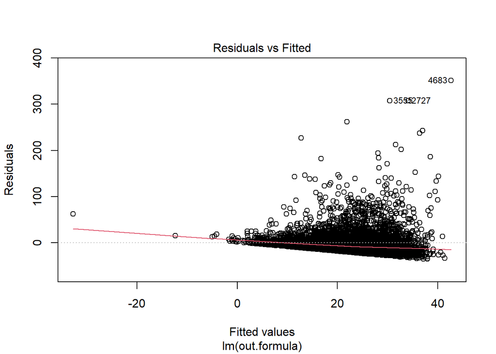

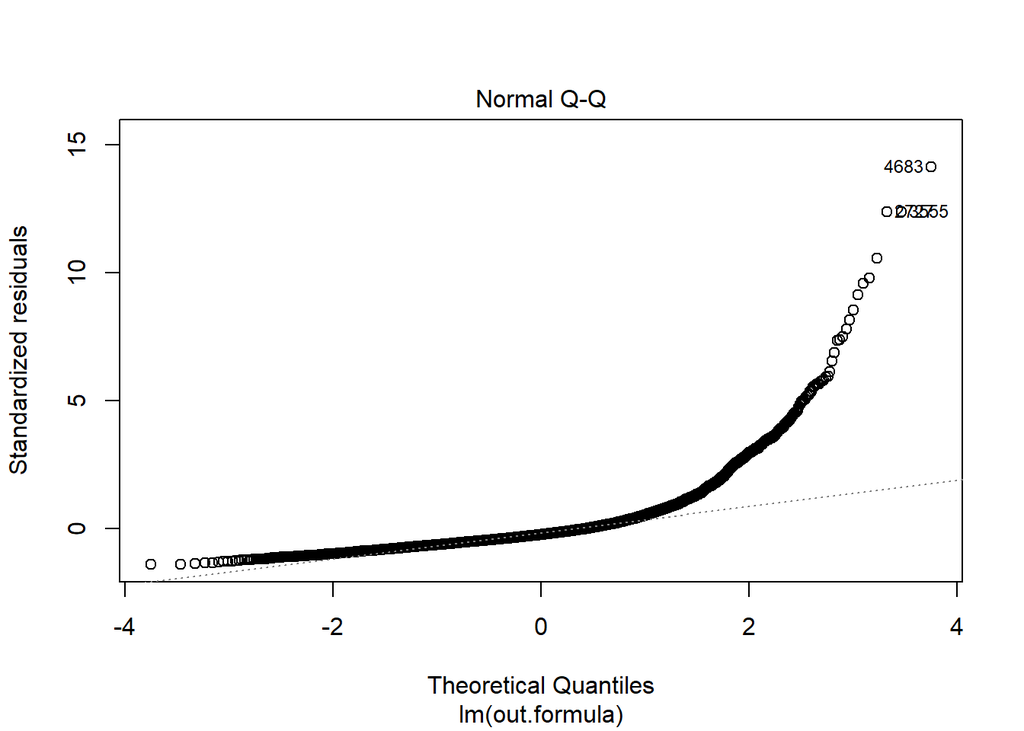

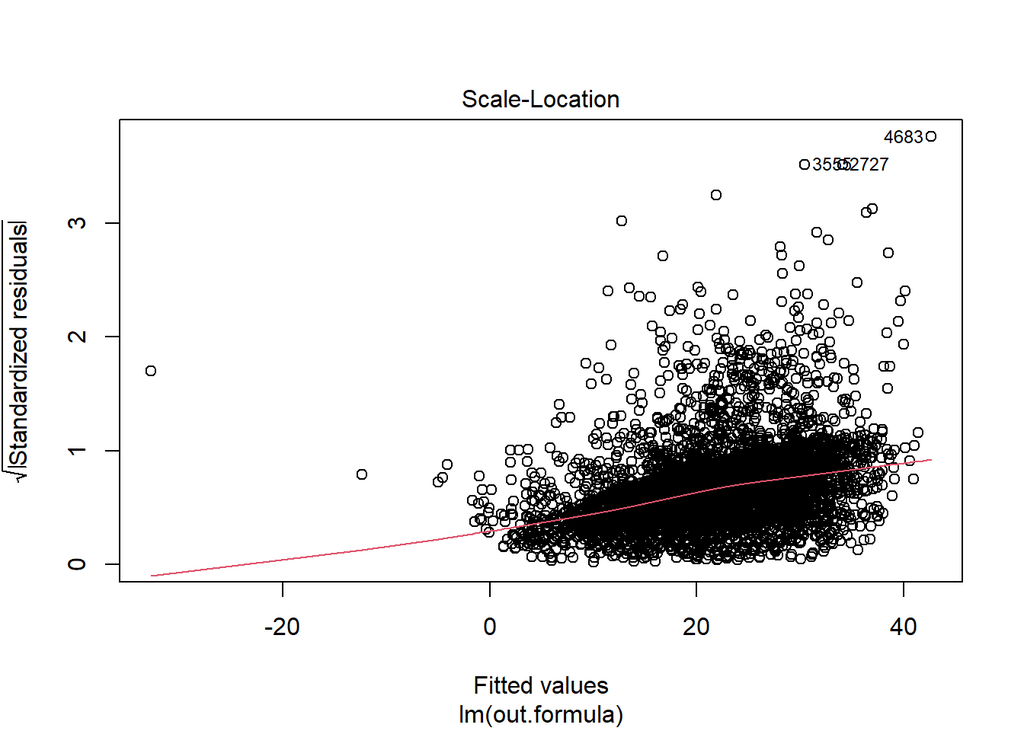

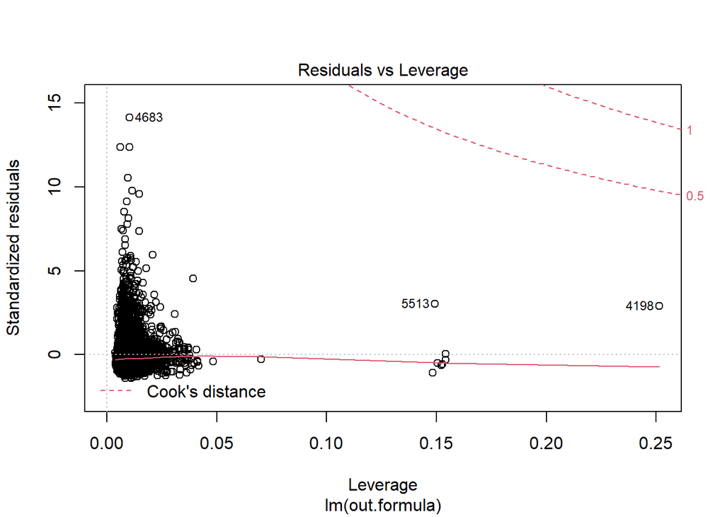

```r
plot(fit1)
```

Diagnostics do not necessarily look so good.

## 1.7 Comparison with literature

Connors et al. (1996) conducted a propensity score matching analysis. Table 5 in Connors et al. (1996) showed that, after propensity score pair (1-to-1) matching, means of length of stay ($Y$), when stratified by RHC ($A$) was significantly different.

### 1.7.1 PSM

We also conduct propensity score pair matching analysis, as follows.

**Note**: In this workshop, we will not cover Propensity Score Matching (PSM) in this workshop. If you want to learn more about this, feel free to check out this other workshop: [Understanding Propensity Score Matching](https://ehsanx.github.io/psw/).

```r
set.seed(123)
require(MatchIt)
ps.formula <- as.formula(paste("A~",
                paste(baselinevars, collapse = "+")))
PS.fit <- glm(ps.formula,family="binomial",
              data=ObsData)
ObsData$PS <- predict(PS.fit,
                      newdata = ObsData, type="response")
```

```r
logitPS <-  -log(1/ObsData$PS - 1)
match.obj <- matchit(ps.formula, data =ObsData,
                     distance = ObsData$PS,
                     method = "nearest", replace=FALSE,
                     ratio = 1, caliper = .1*sd(logitPS))
```

### 1.7.2 PSM diagnostics

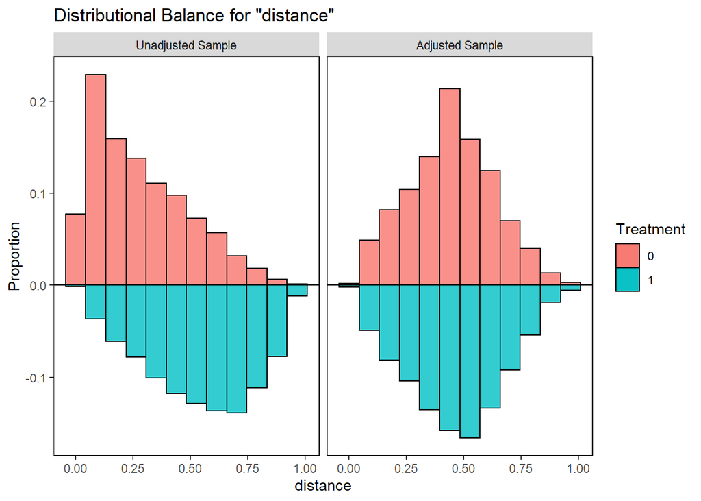

```r
require(cobalt)
bal.plot(match.obj,
         var.name = "distance",
         which = "both",
         type = "histogram",
         mirror = TRUE)
```

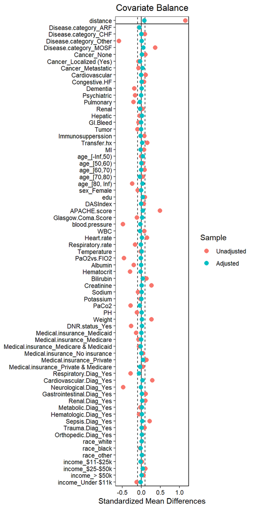

```r
love.plot(match.obj, binary = "std",
          thresholds = c(m = .1))
```

The love plot suggests satisfactory propensity score matching (all SMD < 0.1).

### 1.7.3 PSM results

```r
matched.data <- match.data(match.obj)
tab1y <- CreateTableOne(vars = c("Y"),
               data = matched.data, strata = "A",
               test = TRUE)
print(tab1y, showAllLevels = FALSE,
      test = TRUE)
```

```
##                Stratified by A
##                 0             1             p      test
##   n              1628          1628
##   Y (mean (SD)) 21.20 (25.58) 24.05 (27.49)  0.002
```

We also find the same conclusion based on propensity score pair matched data.

# 2 G-computation

## 2.1 Closer look at the data

```r
# Read the data saved at the last chapter
ObsData <- readRDS(file = "data/rhcAnalytic.RDS")
dim(ObsData)
```

```
## [1] 5735   51
```

### 2.1.1 View data from 6 participants

Let’s focus on only first 6 columns, with only 3 variables.

```r
small.data <- ObsData[1:6,c("sex","A","Y")]
kable(small.data)
```

| sex | A | Y |
| --- | --- | --- |
| Male | 0 | 9 |
| Female | 1 | 45 |
| Female | 1 | 60 |
| Female | 0 | 37 |
| Male | 1 | 2 |
| Female | 0 | 7 |

### 2.1.2 Restructure the data to estimate treatment effect

In causal inference literature, often the data is structured in such a way that the outcomes under different treatments are in different columns:

```r
small.data$id <- c("John","Emma","Isabella","Sophia","Luke", "Mia")
small.data$Y1 <- ifelse(small.data$A==1, small.data$Y, NA)
small.data$Y0 <- ifelse(small.data$A==0, small.data$Y, NA)
small.data$TE <- small.data$Y1 - small.data$Y0
small.data <- small.data[c("id", "sex","A","Y1","Y0", "TE")]
small.data$Y <- NULL
small.data$sex <- as.character(small.data$sex)
m.Y1 <- mean(small.data$Y1, na.rm = TRUE)
m.Y0 <- mean(small.data$Y0, na.rm = TRUE)
mean.values <- round(c(NA,NA, NA, m.Y1, m.Y0,
                 m.Y1 - m.Y0),0)
small.data2 <- rbind(small.data, mean.values)
kable(small.data2, booktabs = TRUE, digits=1,
             col.names = c("Subject ID","Sex",
                           "RHC status (A)",
                           "Y when A=1 (RHC)",
                           "Y when A=0 (no RHC)",
                           "Treatment Effect"))%>%
  row_spec(7, bold = TRUE, color = "white",
           background = "#D7261E")
```

| Subject ID | Sex | RHC status (A) | Y when A=1 (RHC) | Y when A=0 (no RHC) | Treatment Effect |
| --- | --- | --- | --- | --- | --- |
| John | Male | 0 |  | 9 |  |
| Emma | Female | 1 | 45 |  |  |
| Isabella | Female | 1 | 60 |  |  |
| Sophia | Female | 0 |  | 37 |  |
| Luke | Male | 1 | 2 |  |  |
| Mia | Female | 0 |  | 7 |  |
|  |  |  | 36 | 18 | 18 |

Then it is easy to see

- the mean outcome under treated group (`RHC`)
- the mean outcome under untreated group (`no RHC`)

and the difference between these two means are the treatment effect.

### 2.1.3 Treat the problem as a missing value problem

Instead of just estimating treatment effect on an average level, an alternate could be to

- impute mean outcomes for the treated subjects
- impute mean outcomes for the untreated subjects
- Calculate individual treatment effect estimate
- then calculate the average treatment effect

```r
small.data0 <- small.data
small.data$Y1[is.na(small.data$Y1)] <- round(m.Y1)
small.data$Y0[is.na(small.data$Y0)] <- round(m.Y0)
small.data$TE <- small.data$Y1 - small.data$Y0
m.Y1 <- mean(small.data$Y1)
m.Y0 <- mean(small.data$Y0)
m.TE <- mean(small.data$TE)
mean.values <- round(c(NA,NA, NA, m.Y1, m.Y0, m.TE),0)
small.data2 <- rbind(small.data, mean.values)
kable(small.data2, booktabs = TRUE, digits=1,
             col.names = c("Subject ID","Sex",
                           "RHC status (A)",
                           "Y when A=1 (RHC)",
                           "Y when A=0 (no RHC)",
                           "Treatment Effect"))%>%
  row_spec(7, bold = TRUE, color = "white",
           background = "#D7261E")
```

| Subject ID | Sex | RHC status (A) | Y when A=1 (RHC) | Y when A=0 (no RHC) | Treatment Effect |
| --- | --- | --- | --- | --- | --- |
| John | Male | 0 | 36 | 9 | 27 |
| Emma | Female | 1 | 45 | 18 | 27 |
| Isabella | Female | 1 | 60 | 18 | 42 |
| Sophia | Female | 0 | 36 | 37 | -1 |
| Luke | Male | 1 | 2 | 18 | -16 |
| Mia | Female | 0 | 36 | 7 | 29 |
|  |  |  | 36 | 18 | 18 |

### 2.1.4 Impute better value?

However, assume that the effect of the treatment for male and female are not the same. Then, it might make more sense to impute means specific to males for male subjects, and separately impute means specific to females for female subjects.

```r
small.data <- small.data0
m.Y1m <- mean(small.data$Y1[small.data$sex == "Male"], na.rm = TRUE)
m.Y1f <- mean(small.data$Y1[small.data$sex == "Female"], na.rm = TRUE)
m.Y0m <- mean(small.data$Y0[small.data$sex == "Male"], na.rm = TRUE)
m.Y0f <- mean(small.data$Y0[small.data$sex == "Female"], na.rm = TRUE)
m.TE.m <- m.Y1m-m.Y0m
m.TE.f <- m.Y1f-m.Y0f
mean.values.m <- round(c(NA,NA, NA, m.Y1m, m.Y0m, m.TE.m),0)
mean.values.f <- round(c(NA,NA, NA, m.Y1f, m.Y0f, m.TE.f),0)
small.data$Y1[small.data$sex ==
                "Male"][is.na(small.data$Y1[small.data$sex ==
                                              "Male"])] <- round(m.Y1m)
small.data$Y0[small.data$sex ==
                "Male"][is.na(small.data$Y0[small.data$sex ==
                                              "Male"])] <- round(m.Y0m)
small.data$Y1[small.data$sex ==
                "Female"][is.na(small.data$Y1[small.data$sex ==
                                                "Female"])] <- round(m.Y1f)
small.data$Y0[small.data$sex ==
                "Female"][is.na(small.data$Y0[small.data$sex ==
                                                "Female"])] <- round(m.Y0f)
small.data$TE <- small.data$Y1 - small.data$Y0
small.data2 <- rbind(small.data, mean.values.m,mean.values.f)
kable(small.data2, booktabs = TRUE, digits=1,
             col.names = c("Subject ID","Sex","RHC status (A)",
                           "Y when A=1 (RHC)", "Y when A=0 (no RHC)",
                           "Treatment Effect"))%>%
  row_spec(7, bold = TRUE, color = "white", background = "#D7261E")%>%
  row_spec(8, bold = TRUE, color = "white", background = "#D7261E")
```

| Subject ID | Sex | RHC status (A) | Y when A=1 (RHC) | Y when A=0 (no RHC) | Treatment Effect |
| --- | --- | --- | --- | --- | --- |
| John | Male | 0 | 2 | 9 | -7 |
| Emma | Female | 1 | 45 | 22 | 23 |
| Isabella | Female | 1 | 60 | 22 | 38 |
| Sophia | Female | 0 | 52 | 37 | 15 |
| Luke | Male | 1 | 2 | 9 | -7 |
| Mia | Female | 0 | 52 | 7 | 45 |
|  |  |  | 2 | 9 | -7 |
|  |  |  | 52 | 22 | 30 |

- Extending the problem to other covariates, you can see that we could condition on rest of the covariates (such as age, income, race, disease category) to get better imputation values.
- Regression is a generalized method to take mean conditional on many covariates.

## 2.2 Use Regression for predicting outcome

Let us fit the outcome with all covariates, including the exposure status.

```r
# isolate the names of baseline covariates
baselinevars <- names(dplyr::select(ObsData, !c(A,Y)))
# adjust the exposure variable (primary interest) + covariates
out.formula <- as.formula(paste("Y~ A +",
                               paste(baselinevars,
                                     collapse = "+")))
fit1 <- lm(out.formula, data = ObsData)
coef(fit1)
```

```
##                          (Intercept)                                    A
##                        -7.680847e+01                         2.902030e+00
##                  Disease.categoryCHF                Disease.categoryOther
##                        -5.594331e+00                        -4.421893e+00
##                 Disease.categoryMOSF                CancerLocalized (Yes)
##                         2.873451e+00                        -7.794459e+00
##                     CancerMetastatic                      Cardiovascular1
##                        -1.056549e+01                         6.605038e-01
##                       Congestive.HF1                            Dementia1
##                        -1.754818e+00                        -1.261136e+00
##                         Psychiatric1                           Pulmonary1
##                        -4.841489e-01                         2.063282e+00
##                               Renal1                             Hepatic1
##                        -6.935923e+00                        -1.523238e+00
##                            GI.Bleed1                               Tumor1
##                        -5.096253e+00                         4.573818e+00
##                   Immunosupperssion1                         Transfer.hx1
##                         1.103694e-01                         1.161342e+00
##                                  MI1                           age[50,60)
##                        -1.650935e+00                         1.429833e-01
##                           age[60,70)                           age[70,80)
##                        -4.055267e-01                        -1.103439e+00
##                         age[80, Inf)                            sexFemale
##                        -2.757278e+00                         8.272236e-01
##                                  edu                             DASIndex
##                         4.775891e-02                        -5.343588e-02
##                         APACHE.score                   Glasgow.Coma.Score
##                        -7.020692e-02                         1.563055e-02
##                       blood.pressure                                  WBC
##                        -1.323182e-02                         3.940879e-02
##                           Heart.rate                     Respiratory.rate
##                         2.244431e-02                        -1.467861e-03
##                          Temperature                          PaO2vs.FIO2
##                         5.086475e-01                        -8.517735e-03
##                              Albumin                           Hematocrit
##                        -2.570965e+00                        -1.951544e-01
##                            Bilirubin                           Creatinine
##                        -9.814574e-02                         5.210509e-01
##                               Sodium                            Potassium
##                         1.365534e-01                         3.447162e-01
```

[output cut: 9 more lines]

```
##                        -2.018369e+00                         3.404743e-01
##               Cardiovascular.DiagYes                 Neurological.DiagYes
##                         3.784972e-01                         3.541516e+00
##             Gastrointestinal.DiagYes                        Renal.DiagYes
##                         2.551541e+00                         1.784893e+00
##                    Metabolic.DiagYes                  Hematologic.DiagYes
##                        -1.161415e+00                        -3.858024e+00
##                       Sepsis.DiagYes                       Trauma.DiagYes
##                         2.716148e-03                         1.112049e+00
##                   Orthopedic.DiagYes                            raceblack
##                         3.543464e+00                        -1.149936e+00
##                            raceother                       income$25-$50k
##                         2.467487e-01                         2.459547e+00
##                         income> $50k                     incomeUnder $11k
##                         4.214815e-01                        -4.284414e-01
```

### 2.2.1 Predict outcome for treated

- Using the regression fit, we can obtain predicted outcome values for the treated.
- We are not only predicting for the unobserved, but also for the observed values when a person was treated.

```r
ObsData$Pred.Y1 <- predict(fit1,
                           newdata = data.frame(A = 1,
                                                dplyr::select(ObsData, !c(A,Y))),
                           type = "response")
mean(ObsData$Pred.Y1)
```

```
## [1] 23.35625
```

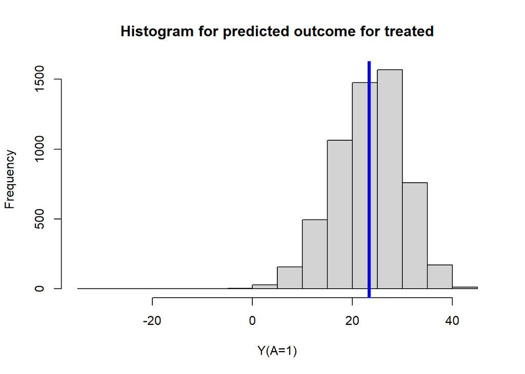

```r
hist(ObsData$Pred.Y1,
     main = "Histogram for predicted outcome for treated",
     xlab = "Y(A=1)")
abline(v=mean(ObsData$Pred.Y1),col="blue", lwd = 4)
```

### 2.2.2 Look at the predicted outcome data for treated

```r
small.data1 <- ObsData[1:6,c("A","Pred.Y1")]
small.data1$id <- c("John","Emma","Isabella","Sophia","Luke", "Mia")
small.data1 <- small.data1[c("id", "A","Pred.Y1")]
kable(small.data1, booktabs = TRUE, digits=1,
             col.names = c("id","RHC status (A)",
                           "Y.hat when A=1 (RHC)"))
```

| id | RHC status (A) | Y.hat when A=1 (RHC) |
| --- | --- | --- |
| John | 0 | 17.5 |
| Emma | 1 | 28.7 |
| Isabella | 1 | 24.6 |
| Sophia | 0 | 21.6 |
| Luke | 1 | 13.6 |
| Mia | 0 | 25.5 |

### 2.2.3 Predict outcome for untreated

```r
ObsData$Pred.Y0 <- predict(fit1,
                           newdata = data.frame(A = 0,
                                                dplyr::select(ObsData, !c(A,Y))),
                           type = "response")
```

Mean predicted outcome for untreated

```r
mean(ObsData$Pred.Y0)
```

```
## [1] 20.45422
```

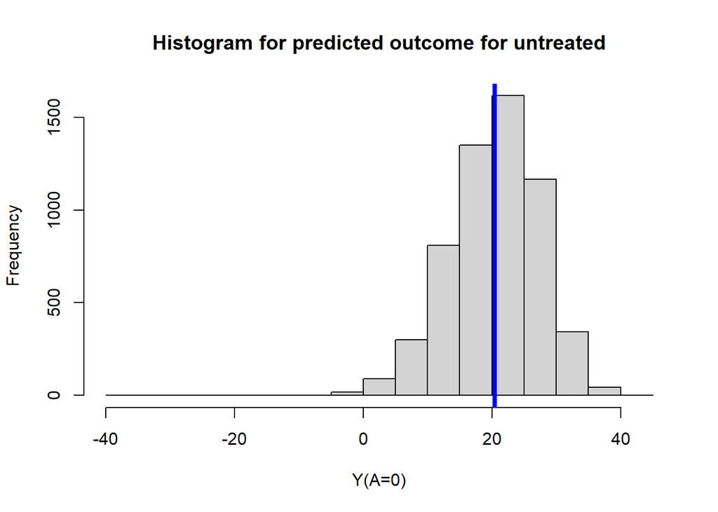

```r
hist(ObsData$Pred.Y0,
     main = "Histogram for predicted outcome for untreated",
     xlab = "Y(A=0)")
abline(v=mean(ObsData$Pred.Y0),col="blue", lwd = 4)
```

### 2.2.4 Look at the predicted outcome data for untreated

```r
small.data0 <- ObsData[1:6,c("A","Pred.Y0")]
small.data0$id <- c("John","Emma","Isabella","Sophia","Luke", "Mia")
small.data0 <- small.data0[c("id", "A","Pred.Y0")]
kable(small.data0, booktabs = TRUE, digits=1,
             col.names = c("id","RHC status (A)",
                           "Y.hat when A=0 (no RHC)"))
```

| id | RHC status (A) | Y.hat when A=0 (no RHC) |
| --- | --- | --- |
| John | 0 | 14.6 |
| Emma | 1 | 25.8 |
| Isabella | 1 | 21.7 |
| Sophia | 0 | 18.7 |
| Luke | 1 | 10.7 |
| Mia | 0 | 22.6 |

### 2.2.5 Look at the predicted outcome data for all!

```r
small.data01 <- small.data1
small.data01$Pred.Y0 <- small.data0$Pred.Y0
small.data01$Pred.TE <- small.data01$Pred.Y1 - small.data01$Pred.Y0
m.Y1 <- mean(small.data01$Pred.Y1)
m.Y0 <- mean(small.data01$Pred.Y0)
mean.values <- round(c(NA,NA, m.Y1, m.Y0, m.Y1 -m.Y0),1)
small.data2 <- rbind(small.data01, mean.values)
kable(small.data2, booktabs = TRUE, digits=1,
             col.names = c("id","RHC status (A)",
                           "Y.hat when A=1 (RHC)",
                           "Y.hat when A=0 (no RHC)",
                           "Treatment Effect"))%>%
  row_spec(7, bold = TRUE, color = "white", background = "#D7261E")
```

| id | RHC status (A) | Y.hat when A=1 (RHC) | Y.hat when A=0 (no RHC) | Treatment Effect |
| --- | --- | --- | --- | --- |
| John | 0 | 17.5 | 14.6 | 2.9 |
| Emma | 1 | 28.7 | 25.8 | 2.9 |
| Isabella | 1 | 24.6 | 21.7 | 2.9 |
| Sophia | 0 | 21.6 | 18.7 | 2.9 |
| Luke | 1 | 13.6 | 10.7 | 2.9 |
| Mia | 0 | 25.5 | 22.6 | 2.9 |
|  |  | 21.9 | 19.0 | 2.9 |

From this table, it is easy to calculate treatment effect estimate. The process we just went through, is a simplified version of **parametric G-computation**!

## 2.3 Parametric G-computation

### 2.3.1 Steps

1. Fit the outcome regression on the exposure and covariates
2. Extract outcome prediction by setting all $A=1$
3. Extract outcome prediction by setting all $A=0$
4. Substract these two outcome predictions to get treatment effect estimate

```r
out.formula <- as.formula(paste("Y~ A +",
                               paste(baselinevars,
                                     collapse = "+")))
fit1 <- lm(out.formula, data = ObsData)
ObsData$Pred.Y1 <- predict(fit1,
                           newdata = data.frame(A = 1,
                                                dplyr::select(ObsData, !c(A,Y))),
                           type = "response")
ObsData$Pred.Y0 <- predict(fit1,
                           newdata = data.frame(A = 0,
                                                dplyr::select(ObsData, !c(A,Y))),
                           type = "response")
ObsData$Pred.TE <- ObsData$Pred.Y1 - ObsData$Pred.Y0
```

### 2.3.2 Treatment effect estimate

Mean value of predicted treatment effect

```r
mean(ObsData$Pred.TE)
```

```
## [1] 2.90203
```

SD of treatment effect

```r
sd(ObsData$Pred.TE)
```

```
## [1] 5.132733e-15
```

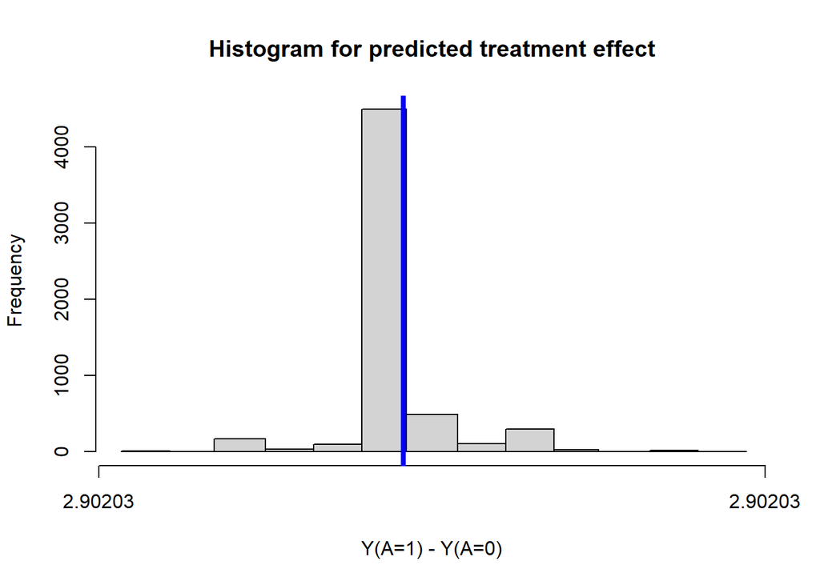

```r
hist(ObsData$Pred.TE, main = "Histogram for predicted treatment effect", xlab = "Y(A=1) - Y(A=0)")
abline(v=mean(ObsData$Pred.TE),col="blue", lwd = 4)
```

G-computation is highly sensitive to on model misspecification. Therefore, it is usually a good idea to use machine learning mehods that are flexible.

# 3 G-computation using ML

## 3.1 G-comp using Regression tree

```r
# Read the data saved at the last chapter
ObsData <- readRDS(file = "data/rhcAnalytic.RDS")
dim(ObsData)
```

```
## [1] 5735   51
```

### 3.1.1 A tree based algorithm

XGBoost is a fast version of gradient boosting algorithm. Let us use this one to fit the data first.

```r
require(xgboost)
Y <-ObsData$Y
ObsData.matrix <- model.matrix(out.formula, data = ObsData)
fit3 <- xgboost(data = ObsData.matrix,
                label = Y,
                max.depth = 10,
                eta = 1,
                nthread = 15,
                nrounds = 100,
                alpha = 0.5,
                objective = "reg:squarederror",
                verbose = 0)
```

### 3.1.2 Extract outcome prediction as if everyone is treated

```r
ObsData.matrix.A1 <- ObsData.matrix
ObsData.matrix.A1[,"A"] <- 1
ObsData$Pred.Y1 <- predict(fit3, newdata = ObsData.matrix.A1)
summary(ObsData$Pred.Y1)
```

```
##    Min. 1st Qu.  Median    Mean 3rd Qu.    Max.
## -24.061   7.997  15.990  23.417  29.978 393.987
```

### 3.1.3 Extract outcome prediction as if everyone is untreated

```r
ObsData.matrix.A0 <- ObsData.matrix
ObsData.matrix.A0[,"A"] <- 0
ObsData$Pred.Y0 <- predict(fit3, newdata = ObsData.matrix.A0)
summary(ObsData$Pred.Y0)
```

```
##    Min. 1st Qu.  Median    Mean 3rd Qu.    Max.
## -43.192   6.914  13.004  20.189  24.827 337.984
```

### 3.1.4 Treatment effect estimate

```r
ObsData$Pred.TE <- ObsData$Pred.Y1 - ObsData$Pred.Y0
```

Mean value of predicted treatment effect

```r
summary(ObsData$Pred.TE)
```

```
##      Min.   1st Qu.    Median      Mean   3rd Qu.      Max.
## -195.6580   -0.9165    0.7056    3.2275    7.5578  177.9588
```

## 3.2 G-comp using regularized methods

### 3.2.1 A regularized model

LASSO is a regularized method. Let us use this one to fit the data first.

```r
require(glmnet)
Y <-ObsData$Y
ObsData.matrix <- model.matrix(out.formula, data = ObsData)
fit4 <-  cv.glmnet(x = ObsData.matrix,
                y = Y,
                alpha = 0.5,
                relax=TRUE)
```

### 3.2.2 Extract outcome prediction as if everyone is treated

```r
ObsData.matrix.A1 <- ObsData.matrix
ObsData.matrix.A1[,"A"] <- 1
ObsData$Pred.Y1 <- predict(fit4, newx = ObsData.matrix.A1,
                           s = "lambda.min")
summary(ObsData$Pred.Y1)
```

```
##        1
##  Min.   :-29.76
##  1st Qu.: 19.31
##  Median : 23.92
##  Mean   : 23.26
##  3rd Qu.: 27.55
##  Max.   : 40.56
```

### 3.2.3 Extract outcome prediction as if everyone is untreated

```r
ObsData.matrix.A0 <- ObsData.matrix
ObsData.matrix.A0[,"A"] <- 0
ObsData$Pred.Y0 <- predict(fit4, newx = ObsData.matrix.A0,
                           s = "lambda.min")
summary(ObsData$Pred.Y0)
```

```
##        1
##  Min.   :-32.50
##  1st Qu.: 16.57
##  Median : 21.18
##  Mean   : 20.52
##  3rd Qu.: 24.81
##  Max.   : 37.82
```

### 3.2.4 Treatment effect estimate

```r
ObsData$Pred.TE <- ObsData$Pred.Y1 - ObsData$Pred.Y0
```

Mean value of predicted treatment effect

```r
summary(ObsData$Pred.TE)
```

```
##        1
##  Min.   :2.74
##  1st Qu.:2.74
##  Median :2.74
##  Mean   :2.74
##  3rd Qu.:2.74
##  Max.   :2.74
```

## 3.3 G-comp using SuperLearner

### 3.3.1 SuperLearner

SuperLearner is an ensemble learning method. Let us use this one to fit the data first.

```r
require(SuperLearner)
ObsData.noY <- dplyr::select(ObsData, !Y)
fit.sl <- SuperLearner(Y=ObsData$Y,
                       X=ObsData.noY,
                       cvControl = list(V = 3),
                       SL.library=c("SL.glm", "SL.glmnet", "SL.xgboost"),
                       family="gaussian")
```

```r
fit.sl$cvRisk
```

```
##     SL.glm_All  SL.glmnet_All SL.xgboost_All
##       632.5495       619.5360       710.2224
```

```r
fit.sl$coef
```

```
##     SL.glm_All  SL.glmnet_All SL.xgboost_All
##      0.0000000      0.8337025      0.1662975
```

```r
all.pred <- predict(fit.sl, type = "response")
head(all.pred$library.predict)
```

```
##   SL.glm_All SL.glmnet_All SL.xgboost_All
## 1   14.61647      14.69992      10.714263
## 2   28.66305      28.41146      37.769444
## 3   24.57800      24.56540      49.425877
## 4   18.70422      19.32453      23.823536
## 5   13.64956      12.52687       6.374265
## 6   22.56895      22.39720      12.713717
```

```r
round(all.pred$pred[1:6,],1)
```

```
##    1    2    3    4    5    6
## 14.0 30.0 28.7 20.1 11.5 20.8
```

### 3.3.2 Extract outcome prediction as if everyone is treated

```r
ObsData.noY$A <- 1
ObsData$Pred.Y1 <- predict(fit.sl, newdata = ObsData.noY,
                           type = "response")$pred
summary(ObsData$Pred.Y1)
```

```
##        V1
##  Min.   :-22.74
##  1st Qu.: 18.32
##  Median : 22.97
##  Mean   : 22.83
##  3rd Qu.: 27.20
##  Max.   : 92.05
```

### 3.3.3 Extract outcome prediction as if everyone is untreated

```r
ObsData.noY$A <- 0
ObsData$Pred.Y0 <- predict(fit.sl, newdata = ObsData.noY,
                           type = "response")$pred
summary(ObsData$Pred.Y0)
```

```
##        V1
##  Min.   :-24.52
##  1st Qu.: 16.23
##  Median : 20.90
##  Mean   : 20.79
##  3rd Qu.: 25.22
##  Max.   : 86.94
```

### 3.3.4 Treatment effect estimate

```r
ObsData$Pred.TE <- ObsData$Pred.Y1 - ObsData$Pred.Y0
```

Mean value of predicted treatment effect

```r
summary(ObsData$Pred.TE)
```

```
##        V1
##  Min.   :0.1468
##  1st Qu.:1.8608
##  Median :2.0250
##  Mean   :2.0392
##  3rd Qu.:2.1970
##  Max.   :5.9969
```

# 4 IPTW

## 4.2 IPTW from ML

## 4.3 IPTW from SuperLearner

# 5 TMLE

## 5.1 Transformation of continuous outcome variable

## 5.2 Initial estimate

## 5.3 Update

```r
# Read the data saved at the last chapter
ObsData <- readRDS(file = "data/rhcAnalytic.RDS")
dim(ObsData)
```

```
## [1] 5735   51
```

# 6 Pre-packaged software

## 6.1 sl3

The *sl3* package implements two types of Super Learning: discrete Super Learning, in which the best prediction algorithm (based on cross-validation) from a specified library is returned, and ensemble Super Learning, in which the best linear combination of the specified algorithms is returned (Coyle, Hejazi, Malenica, et al. (2021)).

The first step is to create a sl3 task which keeps track of the roles of the variables in our problem (Coyle, Hejazi, Melencia, et al. (2021)).

```r
# create sl3 task, specifying outcome and covariates
rhc_task <- make_sl3_Task(
  data = ObsData,
  covariates = colnames(ObsData)[-which(names(ObsData) == "Y")],
  outcome = "Y"
)
rhc_task
```

```
## A sl3 Task with 5735 obs and these nodes:
## $covariates
##  [1] "Disease.category"      "Cancer"                "Cardiovascular"
##  [4] "Congestive.HF"         "Dementia"              "Psychiatric"
##  [7] "Pulmonary"             "Renal"                 "Hepatic"
## [10] "GI.Bleed"              "Tumor"                 "Immunosupperssion"
## [13] "Transfer.hx"           "MI"                    "age"
## [16] "sex"                   "edu"                   "DASIndex"
## [19] "APACHE.score"          "Glasgow.Coma.Score"    "blood.pressure"
## [22] "WBC"                   "Heart.rate"            "Respiratory.rate"
## [25] "Temperature"           "PaO2vs.FIO2"           "Albumin"
## [28] "Hematocrit"            "Bilirubin"             "Creatinine"
## [31] "Sodium"                "Potassium"             "PaCo2"
## [34] "PH"                    "Weight"                "DNR.status"
## [37] "Medical.insurance"     "Respiratory.Diag"      "Cardiovascular.Diag"
## [40] "Neurological.Diag"     "Gastrointestinal.Diag" "Renal.Diag"
## [43] "Metabolic.Diag"        "Hematologic.Diag"      "Sepsis.Diag"
## [46] "Trauma.Diag"           "Orthopedic.Diag"       "race"
## [49] "income"                "A"
##
## $outcome
## [1] "Y"
##
## $id
## NULL
##
## $weights
## NULL
##
## $offset
## NULL
##
## $time
## NULL
```

Next, we create our SuperLearner. To do this, we need to specify a selection of machine learning algorithms we want to include as candidates, as well as a metalearner that the SuperLearner will use to combine or choose from the machine learning algorithms provided (Coyle, Hejazi, Melencia, et al. (2021)).

```r
# see what algorithms are available for a continuous outcome (similar can be done for a binary outcome)
sl3_list_learners("continuous")
```

```
##  [1] "Lrnr_arima"                     "Lrnr_bartMachine"
##  [3] "Lrnr_bilstm"                    "Lrnr_bound"
##  [5] "Lrnr_caret"                     "Lrnr_cv_selector"
##  [7] "Lrnr_dbarts"                    "Lrnr_earth"
##  [9] "Lrnr_expSmooth"                 "Lrnr_gam"
## [11] "Lrnr_gbm"                       "Lrnr_glm"
## [13] "Lrnr_glm_fast"                  "Lrnr_glmnet"
## [15] "Lrnr_grf"                       "Lrnr_gru_keras"
## [17] "Lrnr_gts"                       "Lrnr_h2o_glm"
## [19] "Lrnr_h2o_grid"                  "Lrnr_hal9001"
## [21] "Lrnr_HarmonicReg"               "Lrnr_hts"
## [23] "Lrnr_lstm"                      "Lrnr_lstm_keras"
## [25] "Lrnr_mean"                      "Lrnr_multiple_ts"
## [27] "Lrnr_nnet"                      "Lrnr_nnls"
## [29] "Lrnr_optim"                     "Lrnr_pkg_SuperLearner"
## [31] "Lrnr_pkg_SuperLearner_method"   "Lrnr_pkg_SuperLearner_screener"
## [33] "Lrnr_polspline"                 "Lrnr_randomForest"
## [35] "Lrnr_ranger"                    "Lrnr_rpart"
## [37] "Lrnr_rugarch"                   "Lrnr_screener_correlation"
## [39] "Lrnr_solnp"                     "Lrnr_stratified"
## [41] "Lrnr_svm"                       "Lrnr_tsDyn"
## [43] "Lrnr_xgboost"
```

The chosen candidate algorithms can be created and collected in a Stack.

```r
# initialize candidate learners
lrn_glm <- make_learner(Lrnr_glm)
lrn_lasso <- make_learner(Lrnr_glmnet) # alpha default is 1
lrn_ridge <- Lrnr_glmnet$new(alpha = 0)
xgb_50 <- Lrnr_xgboost$new(nrounds = 50)

# collect learners in stack
stack <- make_learner(
  Stack, lrn_glm, lrn_ridge, lrn_lasso, xgb_50
)
```

The stack is then given to the SuperLearner.

```r
# to make an ensemble SuperLearner
sl <- make_learner(Lrnr_sl, learners = stack)

# or a discrete SuperLearner
sl_disc_meta <- Lrnr_cv_selector$new()
sl_disc <- Lrnr_sl$new(
  learners = stack,
  metalearner = sl_disc_meta
)
```

The SuperLearner is then trained on the sl3 task we created at the start and then it can be used to make predictions.

```r
set.seed(1444)

# train SL
sl_fit <- sl$train(rhc_task)
# or for discrete SL
# sl_fit <- sl_disc$train(rhc_task)

# make predictions
sl_preds <- sl_fit$predict()
head(sl_preds)
```

```
## [1] 14.56827 29.33269 26.27950 20.47232 12.86316 21.42950
```

## 6.2 tmle

```r
set.seed(123)

# transform the outcome to fall within the range [0,1]
a <- min(na.omit(ObsData$Y))
b <- max(na.omit(ObsData$Y))
ObsData$Y <- (ObsData$Y-a)/(b-a)

# run tmle from the tmle package
W <- dplyr::select(ObsData, !c(Y, A))
TMLE_PKG <- tmle::tmle(Y = ObsData$Y, A = ObsData$A, W = W, family = "gaussian")
TMLE_PKG_ATE_tr <- TMLE_PKG$estimates$ATE$psi
# transform back the ATE estimate
TMLE_PKG_ATE <- (b-a)*TMLE_PKG_ATE_tr

cat("ATE from tmle package: ", TMLE_PKG_ATE, "  (", (b-a)*TMLE_PKG$estimates$ATE$CI[1], ", ", (b-a)*TMLE_PKG$estimates$ATE$CI[2], ")", sep = "")
```

```
## ATE from tmle package: 2.730192  (1.11782, 4.342564)
```

## 6.3 ltmle

Similarly to the *tmle* package, the *ltmle* package gives the direct TMLE result with the call of one function.

```r
ltmle_est <- ltmle(ObsData, Anodes = "A", Ynodes = "Y", abar = 1)
```

```
## Qform not specified, using defaults:
```

```
## gform not specified, using defaults:
```

```
## formula for A:
```

```
## A ~ Disease.category + Cancer + Cardiovascular + Congestive.HF +     Dementia + Psychiatric + Pulmonary + Renal + Hepatic + GI.Bleed +     Tumor + Immunosupperssion + Transfer.hx + MI + age + sex +     edu + DASIndex + APACHE.score + Glasgow.Coma.Score + blood.pressure +     WBC + Heart.rate + Re…
```

```
## Timing estimate unavailable
```

[output not shown]

```r
ltmle_est
```

```
## Call:
## ltmle(data = ObsData, Anodes = "A", Ynodes = "Y", abar = 1)
##
## TMLE Estimate:  0.04989636
```

## 6.4 tmle3

## 6.5 AIPW

# 7 Final Words

## 7.1 Why SL and TMLE

### 7.1.1 Prediction goal

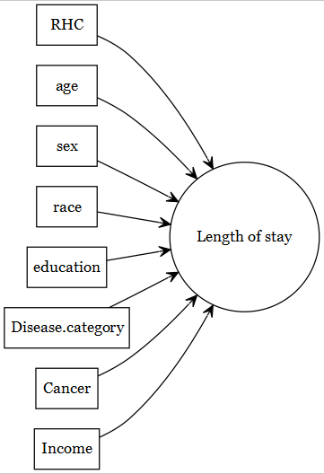

- Assuming all covariates are measured, parametric models such as linear and logistic regressions are very efficient, but relies on strong assumptions. In real-world scenarios, it is often hard (if not impossible) to guess the correct specification of the right hand side of the regression equation.
- Machine learning (ML) methods are very helpful for prediction goals. They are also helpful in identifying complex functions (non-linearities and non-additive terms) of the covariates (again, assuming they are measured).
- There are many ML methods, but the procedures are very different, and they come with their own advantages and disadvantages. In a given real data, it is hard to apriori predict which is the best ML algorithm.
- That’s where super learner is helpful in combining strength from various algorithms, and producing 1 prediction column that has optimal statistical properties.

### 7.1.2 Causal inference

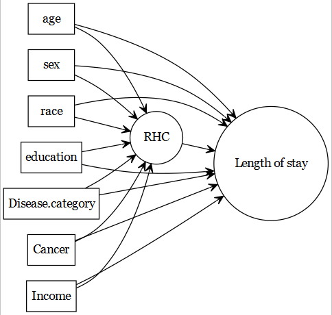

- For causal inference goals (when we have a primary exposure of interest), machine learning methods are often misleading. This is primarily due to the fact that they usually do not have an inherent mechanism of focusing on primary exposure (RHC in this example); and treats the primary exposure as any other predictors.
- When using g-computation with ML methods, estimation of variance becomes a difficult problem. Generalized procedures such as robust SE or bootstrap methods are not supported by theory.
- That’s where TMLE methods shine, with the help of it’s important statistical properties (double robustness, finite sample properties).

### 7.1.3 Identifiability assumptions

However, causal inference requires satisfying identifiability assumptions for us to interpret causality based on association measures from statistical models (see below). Many of these assumptions are not empirically testable. That is why, it is extremely important to work with **subject area experts** to assess the plausibility of those assumptions in the given context. No ML method, no matter how fancy it is, can automatically produce estimates that can be directly interpreted as causal, unless the identifiability assumptions are properly taken into account.

| Conditional Exchangeability | $Y(1), Y(0) \perp A \| L$ | Treatment assignment is independent of the potential outcome, given covariates |
| --- | --- | --- |
| Positivity | $0 < P(A=1 \| L) < 1$ | Subjects are eligible to receive both treatment, given covariates |
| Consistency | $Y = Y(a) \forall A=a$ | No multiple version of the treatment; and well defined treatment |

## 7.2 Further reading

### 7.2.1 Key articles

- TMLE Procedure:
  - Luque-Fernandez et al. (2018)
  - Schuler and Rose (2017)
- Super learner:
  - Rose (2013)
  - Naimi and Balzer (2018)

### 7.2.2 Additional readings

- Rose (2020)
- Snowden, Rose, and Mortimer (2011)
- Naimi, Cole, and Kennedy (2017)
- Austin and Stuart (2015)
- Naimi, Mishler, and Kennedy (2017)
- Balzer and Westling (2021)

### 7.2.3 Workshops

Highly recommend joining SER if interested in Epi methods development. The following workshops are very useful.

- [SER Workshop](https://epiresearch.org/) Introduction to Parametric and Semi-parametric Estimators for Causal Inference by Laura B. Balzer & Jennifer Ahern, 2020
- [SER Workshop](https://epiresearch.org/) Machine Learning and Artificial Intelligence for Causal Inference and Prediction: A Primer by Naimi A, 2021

### 7.2.4 Recorded webinars

The following webinars and workshops are freely accessible, and great for understanding the intuitions, theories and mechanisms behind these methods!

#### 7.2.4.1 Introductory materials

- [An Introduction to Targeted Maximum Likelihood Estimation of Causal Effects](https://www.youtube.com/watch?v=8Q9dfW3oOi4) by Susan Gruber (Putnam Data Sciences)
- [Practical Considerations for Specifying a Super Learner](https://www.youtube.com/watch?v=WYnjja8DKPg) by Rachael Phillips (Putnam Data Sciences)

#### 7.2.4.2 More theory talks

- [Targeted Machine Learning for Causal Inference based on Real World Data](https://www.youtube.com/watch?v=PrPNP5RVcLg) by Mark van der Laan (Putnam Data Sciences)
- [An introduction to Super Learning](https://www.youtube.com/watch?v=1zT17HtvtF8) by Eric Polly (Putnam Data Sciences)
- [Cross-validated Targeted Maximum Likelihood Estimation (CV-TMLE)](https://www.youtube.com/watch?v=MDmddX267Ys) by Alan Hubbard (Putnam Data Sciences)
- [Higher order Targeted Maximum Likelihood Estimation](https://www.youtube.com/watch?v=2jumfnRQpxs) by Mark van der Laan (Online Causal Inference Seminar)
- [Targeted learning for the estimation of drug safety and effectiveness: Getting better answers by asking better questions](http://bcooltv.mcgill.ca/FDownloader.aspx?rid=e3143be2-918d-49d9-82ce-4dfea75ef1dc&DLType=VGAMP4) by Mireille Schnitzer (CNODES)

#### 7.2.4.3 More applied talks

- [Applications of Targeted Maximum Likelihood Estimation](https://www.youtube.com/watch?v=foY7HoCeo88) by Laura Balzar (UCSF Epi & Biostats)
- [Applying targeted maximum likelihood estimation to pharmacoepidemiology](https://www.cnodes.ca/online-lecture/targeted-learning-estimation/) by Menglan Pang (CNODES)

# References

Austin, Peter C, and Elizabeth A Stuart. 2015. “Moving Towards Best Practice When Using Inverse Probability of Treatment Weighting (IPTW) Using the Propensity Score to Estimate Causal Treatment Effects in Observational Studies.” *Statistics in Medicine* 34 (28): 3661–79.

Balzer, Laura B, and Ted Westling. 2021. “Demystifying Statistical Inference When Using Machine Learning in Causal Research.” *American Journal of Epidemiology*.

Connors, Alfred F, Theodore Speroff, Neal V Dawson, Charles Thomas, Frank E Harrell, Douglas Wagner, Norman Desbiens, et al. 1996. “The Effectiveness of Right Heart Catheterization in the Initial Care of Critically III Patients.” *Jama* 276 (11): 889–97. \url{https://tinyurl.com/Connors1996}.

Coyle, Jeremy R, Nima S Hejazi, Ivana Malenica, and Oleg Sofrygin. 2021. *sl3: Modern Pipelines for Machine Learning and Super Learning*. https://github.com/tlverse/sl3. https://doi.org/10.5281/zenodo.1342293.

Coyle, Jeremy R, Nima S Hejazi, Ivana Melencia, Rachael Phillips, and Alex Hubbard. 2021. *Targeted Learning in R: Causal Data Science with the tlverse Software Ecosystem*. https://github.com/tlverse/tlverse-handbook. https://tlverse.org/tlverse-handbook/.

Gruber, S., M. Van Der Laan, and C. Kennedy. 2020. *Package ’Tmle’*. https://cran.r-project.org/web/packages/tmle/tmle.pdf.

Luque-Fernandez, Miguel Angel, Michael Schomaker, Bernard Rachet, and Mireille E Schnitzer. 2018. “Targeted Maximum Likelihood Estimation for a Binary Treatment: A Tutorial.” *Statistics in Medicine* 37 (16): 2530–46.

Naimi, Ashley I, and Laura B Balzer. 2018. “Stacked Generalization: An Introduction to Super Learning.” *European Journal of Epidemiology* 33 (5): 459–64.

Naimi, Ashley I, Stephen R Cole, and Edward H Kennedy. 2017. “An Introduction to g Methods.” *International Journal of Epidemiology* 46 (2): 756–62.

Naimi, Ashley I, Alan E Mishler, and Edward H Kennedy. 2017. “Challenges in Obtaining Valid Causal Effect Estimates with Machine Learning Algorithms.” *arXiv Preprint arXiv:1711.07137*.

Rose, Sherri. 2013. “Mortality Risk Score Prediction in an Elderly Population Using Machine Learning.” *American Journal of Epidemiology* 177 (5): 443–52.

———. 2020. “Intersections of Machine Learning and Epidemiological Methods for Health Services Research.” *International Journal of Epidemiology* 49 (6): 1763–70.

Schuler, Megan S, and Sherri Rose. 2017. “Targeted Maximum Likelihood Estimation for Causal Inference in Observational Studies.” *American Journal of Epidemiology* 185 (1): 65–73.

Snowden, Jonathan M, Sherri Rose, and Kathleen M Mortimer. 2011. “Implementation of g-Computation on a Simulated Data Set: Demonstration of a Causal Inference Technique.” *American Journal of Epidemiology* 173 (7): 731–38.